# Analysis on Flint Water Crisis

Zane Shango, Nicole Jedding

12/7/2019

## Background and Reasoning

Flint, Michigan was once a flourishing city in Michigan’s automobile manufacturing driven economy in most of the 1900s; unfortunately that is no longer the case. Throughout recent years Flint has been struggling to return to the city it once was and sadly there appears to be no end to the city’s struggle in sight. Many things have been factors in the struggles of Flint such as the movement towards non-domestic automobile manufacturing by major companies such as General Motors, and the former rising crime rate (which is now down from what it used to be). But, the most recent and the most nationally recognized, is the recent Flint Water Crisis. We wanted to take a look at some actual test results from the Flint Water Crisis, and display our findings in order to show the fact that action needed to be taken.

# Loading in the Data

We used two data sets for this, one for the plotting and one for the mapping. This plotting data set was named three_test_lead which showed many lead test samples across Flint’s zipcodes, where there was a test taken of the initial water, the water 45 seconds after flushing, and the water 2 minutes after flushing.The flushing refers to the act of opening the faucet fully and “flushing” the lead out of the pipes by running the water for the alloted amount of time per test. These tests were taken from tap water, which is commonly used for: drinking, cooking, dish washing, showering, and just about everything done with water in a household or work setting. The second data set we used for mapping the average lead levels for each Flint zipcode, contained the testing average lead concentrations in the water of residential taps in Flint, MI from May 2015 through June 2016. During this time period, both the State of Michigan and the federal government declared a State of Emergency in the city.

```r
## FINAL PROJECT ##
## ZANE SHANGO, NICOLE JEDDING ##

# load in necessary packages
library(ggplot2)
library(tidyverse)
library(RColorBrewer)
library(maps)
library(reshape2) # needed for melting the dataframe
library(zipcode) # gives the longitude and latitude of the center of each US zipcode
data(zipcode) # this sets the zipcode package as data

# load in data
three_test_lead <- read.csv("flint_water_data.csv") # Flint water data
three_test_lead$Ward <- NULL # get rid of ward column to simplify dataframe
three_test_lead$Notes <- NULL # get rid of mostly empty notes column
three_test_lead$SampleID <- NULL # get rid of sampleID

# turn Zip.Code column to character string, useful for plotting
three_test_lead$Zip.Code <- as.character(three_test_lead$Zip.Code)

# Mapping data
avg_lead <- read.csv("flint_water_data2.csv")

avg_lead_raw <- read.csv("flint_water_data2.csv") # Flint water data
avg_lead <- avg_lead_raw
avg_lead <- na.omit(avg_lead) #remove missing info
```

# Where is Flint, MI Located?

This map of Michigan counties fills in Genesee county to give a perspective of where exactly Flint is. In fact, it’s not too far from East Lansing as it is only about a 45-50 minute drive.

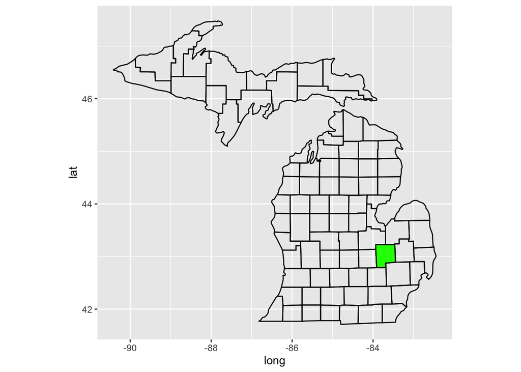

```r
# set county and mi subsets to map Michigan's counties
county <- map_data("county") #  US counties
mi <- subset(county,region=="michigan") # limits the counties to just michigan counties

## CREATE MAP OF MI COUNTIES TO SHOW WHERE GENESSEE COUNTY IS ##
mi_county <- ggplot(data=mi,aes(x=long, y=lat)) +
  geom_polygon(aes(group=group), color = "black", fill=NA) +
  coord_fixed(1.3)

# fill in Genesee county
subsetCounty <- c("genesee")
county2 <- subset(mi, subregion %in% subsetCounty)

# new map with Genesee country filled in
genesee_county <- mi_county +
  geom_polygon(data = county2, aes(x=long, y=lat, group=group),fill = "green", color = "black") +
  coord_fixed(1.3)
genesee_county
```

# Each Test’s Results by Zipcode

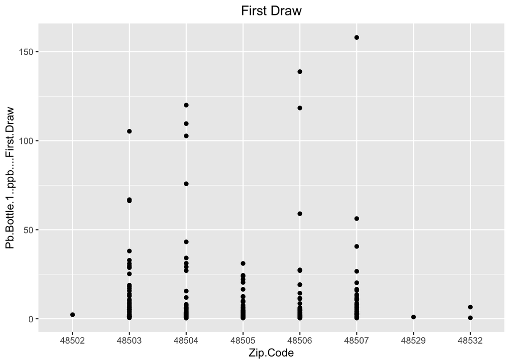

```r
## NOW BEGIN WORKING WITH THREE TEST LEAD DATA ##
# find unique zip code values for three test lead
flint_zipcodes <- unique(three_test_lead$Zip.Code)

# create plots showing the lead levels for the 1st test, a test 45 seconds after flushing, and a test 2 minutes after flushing
# hjust of .5 in order to center the plot's title

# plot for the first test, done with initial water sample
first_draw <- ggplot(three_test_lead,aes(x=Zip.Code, y=Pb.Bottle.1..ppb....First.Draw )) + geom_point() +
  ggtitle("First Draw") + theme(plot.title = element_text(hjust = .5))
# average lead level for first draw
avg_first_test <- mean(three_test_lead$Pb.Bottle.1..ppb....First.Draw)


# plot for second test, done with water sample 45 seconds after flushing, set range up to 300, so it will
# not plot the outlier value over 1,000 (I believe it was entered incorrectly)
forty_five <- ggplot(three_test_lead, aes(x=Zip.Code, y=Pb.Bottle.2..ppb....45.secs.flushing)) + geom_point() +
  ggtitle("45 Seconds after Flushing") + theme(plot.title = element_text(hjust = .5)) + ylim(0,300)
# average lead level for 45 sec test
avg_45sec_test <- mean(three_test_lead$Pb.Bottle.2..ppb....45.secs.flushing)

# plot for the third test, done with water sample 2 minutes after flushing
two_min <- ggplot(three_test_lead, aes(x=Zip.Code, y=Pb.Bottle.3..ppb....2.mins.flushing)) + geom_point() +
  ggtitle("2 Minutes after Flushing") + theme(plot.title = element_text(hjust = .5))
# average lead level for 2 min test
avg_2min_test <- mean(three_test_lead$Pb.Bottle.3..ppb....2.mins.flushing)

# all of these on one plot
# melt the dataframe, set the identification variable as the zipcode, and the variable we're interested
# in as which test it is, the value is the lead level result from each test
flint_melt <-  melt(three_test_lead ,  id.vars = 'Zip.Code', variable.name = 'test')
# make a plot with the melted dataframe that colors the dots according to which test was done
# the horizontal line with the annotation of Unhealthy represents the level of lead that is considered
# unhealthy in tap water, where action needs to be taken (15 ppb)
melt_plot <- ggplot(flint_melt,aes(x=Zip.Code, y=value, color = test)) + geom_point() +
  theme(axis.text.x = element_text(angle = 60, hjust = 1)) + ggtitle("Test Results by Zipcode") +
  theme(plot.title = element_text(hjust = .5)) + ylab("Lead Pb (ppb)") + xlab("Zip Code") + ylim(0,300) +
  geom_hline(yintercept=15, color = "purple") + annotate("text", x ="", y = 15, label = "         Unhealthy", vjust = -0.5)
first_draw
```

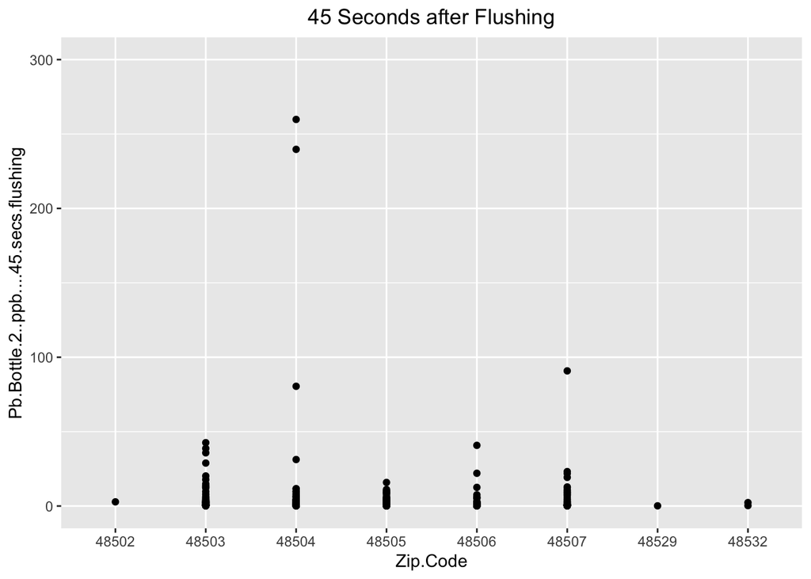

```r
forty_five
```

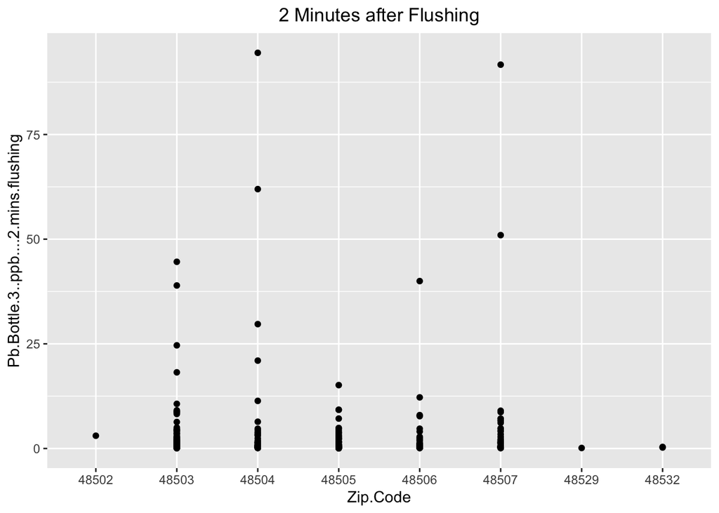

```r
two_min
```

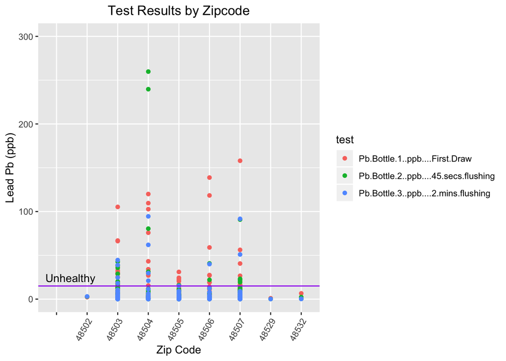

```r
melt_plot
```

These plots show a few things, firstly the average lead level in ppb was the highest on the first draw, which would make sense as the residents were told to “flush” the faucet to essentially rise the lead off the pipes prior to using it, so without flushing the average would naturally be higher. However, the average lead level after flushing for 45 seconds was only .35 ppb lower than not flushing at all. This shows that you need to flush the pipes for a long period of time, which is not only very time consuming but it is wasteful as well. By melting the dataframe and plotting all the data onto one graph, you can see the distribution of lead levels is not equal amongst each zipcode, and there were a lot of tests above the unhealthy level even though the averages were below. While the averages in these plots are not anything higher than the unhealthy level of 15ppb (the highest is 10.65ppb), this is due to some zipcodes having worse lead levels than others.

# Plotting Each Zipcode’s Test Results

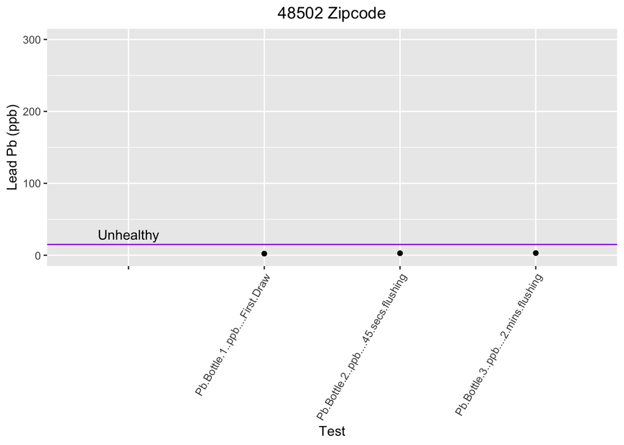

```r
# plots for each zipcode
# these will show all of the observations for each zipcode, the x axis will be each test, y axis the results
# the unhealthy horizontal line is on these as well to put the unhealthy level into perspective
five_zero_two <- subset(flint_melt, Zip.Code == 48502)
five_zero_two_plot <- ggplot(five_zero_two, aes(x=test, y=value)) + geom_point() +
  theme(axis.text.x = element_text(angle = 60, hjust = 1)) + ggtitle("48502 Zipcode") +
  theme(plot.title = element_text(hjust = .5)) + ylab("Lead Pb (ppb)") + xlab("Test") + ylim(0,300) +
  geom_hline(yintercept=15, color = "purple") + annotate("text", x ="", y = 15, label = "Unhealthy", vjust = -0.5)
# average lead level for 48502
avg_502_alltests <- mean(five_zero_two$value)

five_zero_three <- subset(flint_melt, Zip.Code == 48503)
five_zero_three_plot <- ggplot(five_zero_three, aes(x=test, y=value)) + geom_point() +
  theme(axis.text.x = element_text(angle = 60, hjust = 1)) + ggtitle("48503 Zipcode") +
  theme(plot.title = element_text(hjust = .5)) + ylab("Lead Pb (ppb)") + xlab("Test") + ylim(0,300) +
  geom_hline(yintercept=15, color = "purple") + annotate("text", x ="", y = 15, label = "Unhealthy", vjust = -0.5)
# average lead level for 48503
avg_503_alltests <- mean(five_zero_three$value)

five_zero_four <- subset(flint_melt, Zip.Code == 48504)
five_zero_four_plot <- ggplot(five_zero_four, aes(x=test, y=value)) + geom_point() +
  theme(axis.text.x = element_text(angle = 60, hjust = 1)) + ggtitle("48504 Zipcode") +
  theme(plot.title = element_text(hjust = .5)) + ylab("Lead Pb (ppb)") + xlab("Test") + ylim(0,300) +
  geom_hline(yintercept=15, color = "purple") + annotate("text", x ="", y = 15, label = "Unhealthy", vjust = -0.5)
# average lead level for 48504
avg_504_alltests <- mean(five_zero_four$value)

five_zero_five <- subset(flint_melt, Zip.Code == 48505)
five_zero_five_plot <- ggplot(five_zero_five, aes(x=test, y=value)) + geom_point() +
  theme(axis.text.x = element_text(angle = 60, hjust = 1)) + ggtitle("48505 Zipcode") +
  theme(plot.title = element_text(hjust = .5)) + ylab("Lead Pb (ppb)") + xlab("Test") + ylim(0,300) +
  geom_hline(yintercept=15, color = "purple") + annotate("text", x ="", y = 15, label = "Unhealthy", vjust = -0.5)
# average lead level fro 48505
avg_505_alltests <- mean(five_zero_five$value)

five_zero_six <- subset(flint_melt, Zip.Code == 48506)
five_zero_six_plot <- ggplot(five_zero_six, aes(x=test, y=value)) + geom_point() +
  theme(axis.text.x = element_text(angle = 60, hjust = 1)) + ggtitle("48506 Zipcode") +
  theme(plot.title = element_text(hjust = .5)) + ylab("Lead Pb (ppb)") + xlab("Test") + ylim(0,300) +
  geom_hline(yintercept=15, color = "purple") + annotate("text", x ="", y = 15, label = "Unhealthy", vjust = -0.5)
# average lead level for 48506
avg_506_alltests <- mean(five_zero_six$value)

five_zero_seven <- subset(flint_melt, Zip.Code == 48507)
five_zero_seven_plot <- ggplot(five_zero_seven, aes(x=test, y=value)) + geom_point() +
  theme(axis.text.x = element_text(angle = 60, hjust = 1)) + ggtitle("48507 Zipcode") +
  theme(plot.title = element_text(hjust = .5)) + ylab("Lead Pb (ppb)") + xlab("Test") + ylim(0,300) +
  geom_hline(yintercept=15, color = "purple") + annotate("text", x ="", y = 15, label = "Unhealthy", vjust = -0.5)
avg_507_alltests <- mean(five_zero_seven$value)

five_two_nine <- subset(flint_melt, Zip.Code == 48529)
five_two_nine_plot <- ggplot(five_two_nine, aes(x=test, y=value)) + geom_point() +
  theme(axis.text.x = element_text(angle = 60, hjust = 1)) + ggtitle("48529 Zipcode") +
  theme(plot.title = element_text(hjust = .5)) + ylab("Lead Pb (ppb)") + xlab("Test") + ylim(0,300) +
  geom_hline(yintercept=15, color = "purple") + annotate("text", x ="", y = 15, label = "Unhealthy", vjust = -0.5)
# average lead level for 48529
avg_529_alltests <- mean(five_two_nine$value)

five_three_two <- subset(flint_melt, Zip.Code == 48532)
five_three_two_plot <- ggplot(five_three_two, aes(x=test, y=value)) + geom_point() +
  theme(axis.text.x = element_text(angle = 60, hjust = 1)) + ggtitle("48532 Zipcode") +
  theme(plot.title = element_text(hjust = .5)) + ylab("Lead Pb (ppb)") + xlab("Test") + ylim(0,300) +
  geom_hline(yintercept=15, color = "purple") + annotate("text", x ="", y = 15, label = "Unhealthy", vjust = -0.5)
# average lead level for 48532
avg_532_alltests <- mean(five_three_two$value)

five_zero_two_plot
```

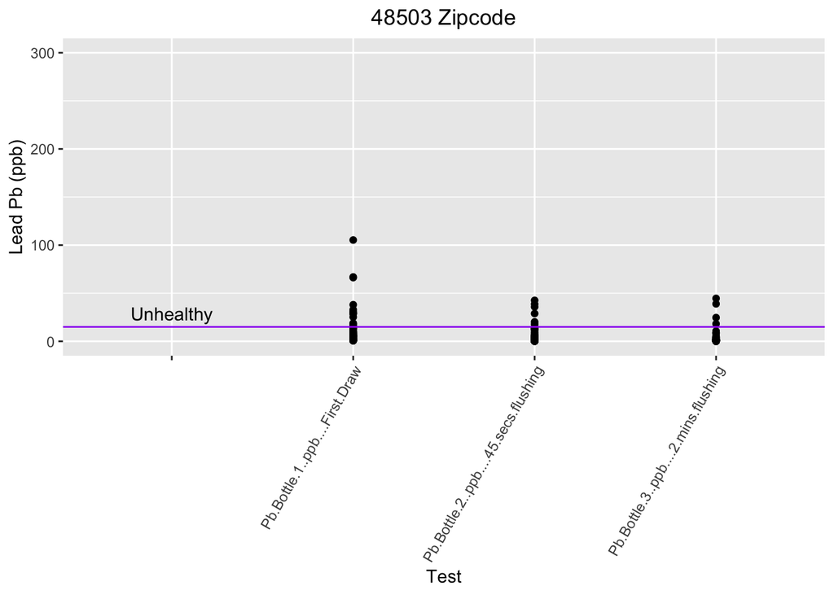

```r
five_zero_three_plot
```

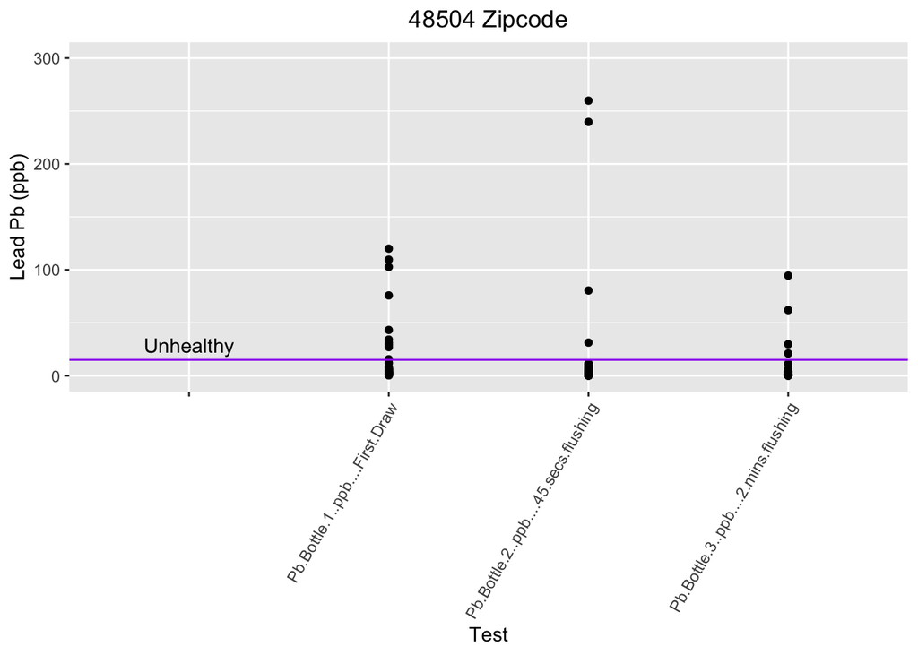

```r
five_zero_four_plot
```

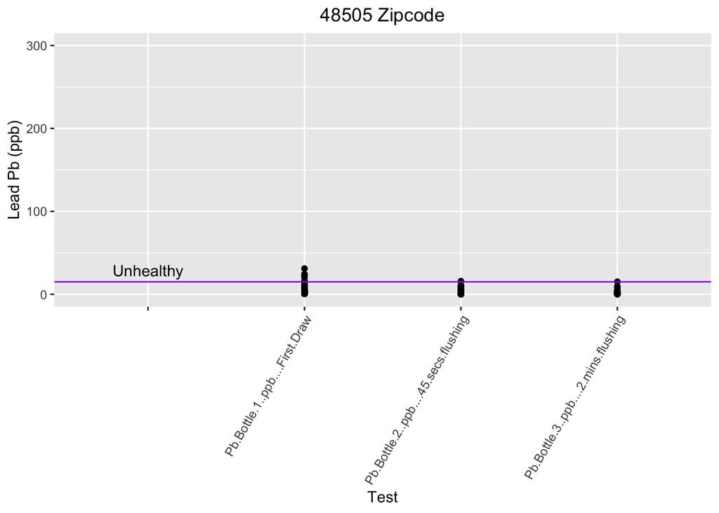

```r
five_zero_five_plot
```

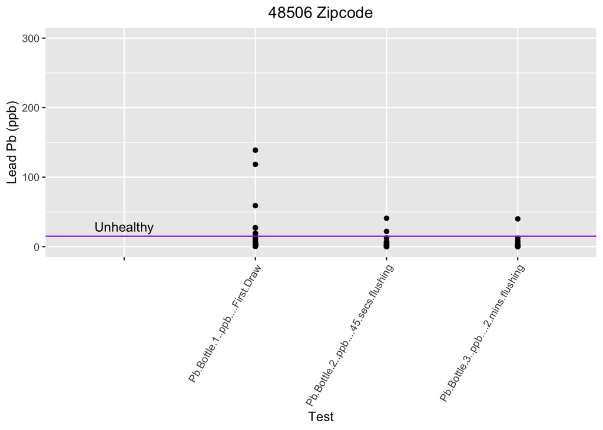

```r
five_zero_six_plot
```

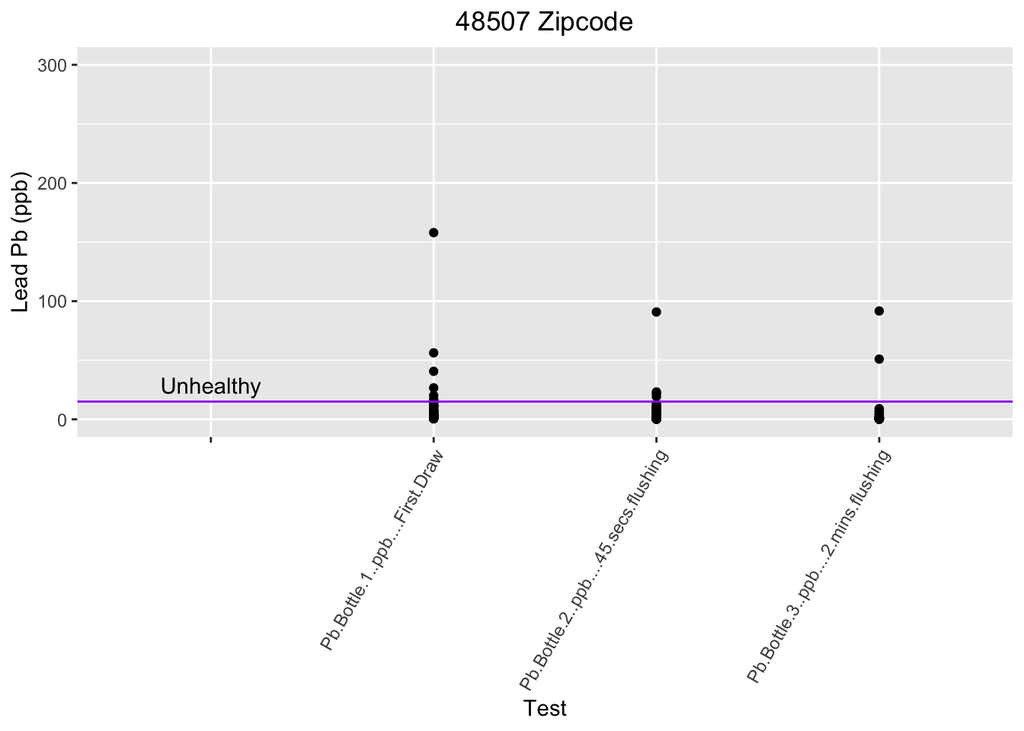

```r
five_zero_seven_plot
```

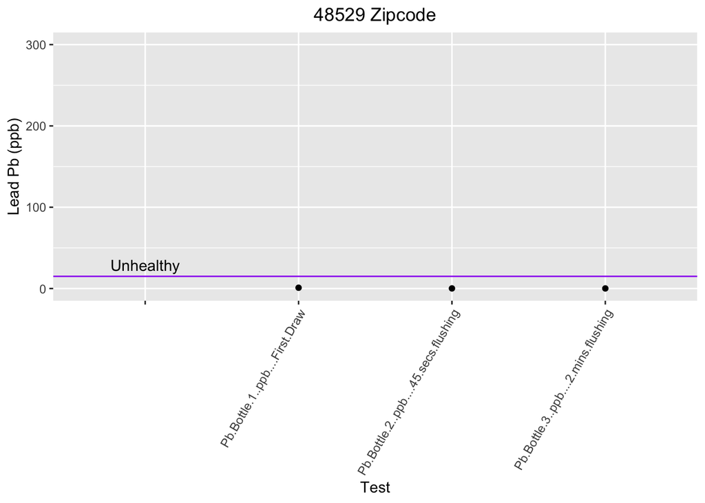

```r
five_two_nine_plot
```

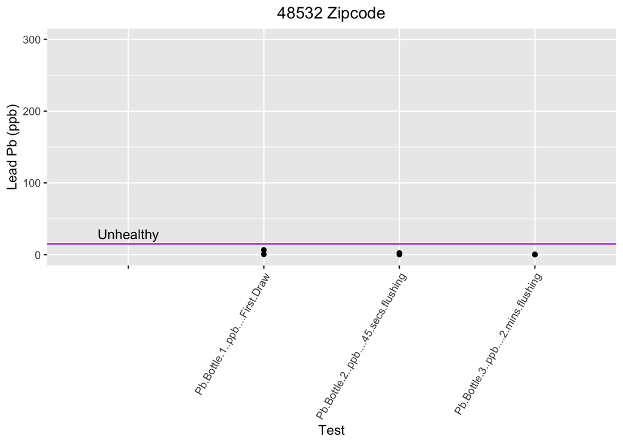

```r
five_three_two_plot
```

As you can see, many zipcodes are much worse than others are. There were 4 zipcodes with an average lead level above 5ppb and one of them had an average lead level above 15ppb. The 48504 zipcode is on Flint’s west side and contains a large portion of the downtown area, it’s average lead level across the tests was 16.97 ppb. This shows that this problem was not affecting every household the same way, but large areas of Flint were being supplied with tap water with lead levels higher than the EPA unhealthy to drink level of 15ppb. This was a major problem, and today it still affects many residents, and action needed to be taken much earlier than it was.

# Zipcode Map

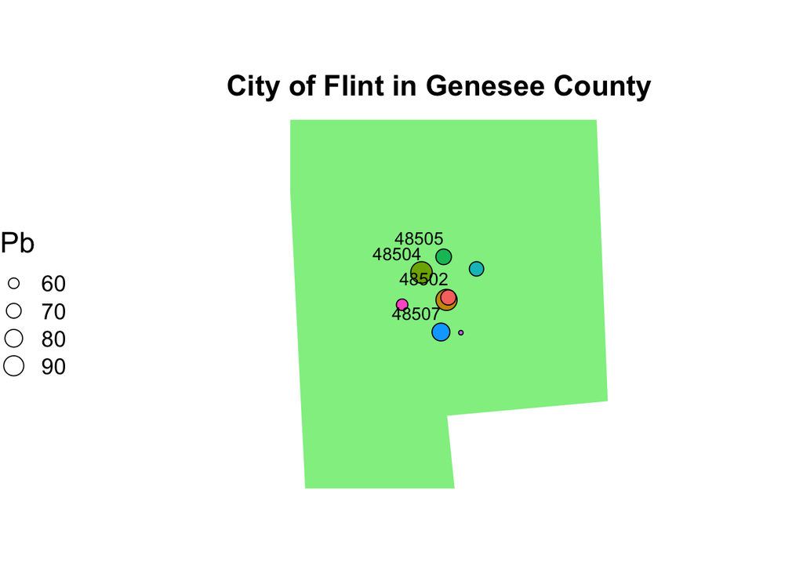

```r
flint_zips <- subset(zipcode, zip == 48504 | zipcode$zip == 48507 | zipcode$zip == 48505 | zipcode$zip == 48503 | zipcode$zip == 48506 | zipcode$zip == 48529 | zipcode$zip == 48532 | zipcode$zip == 48502)

avg_lead <- read.csv("flint_water_data2.csv")

avg_lead_raw <- read.csv("flint_water_data2.csv") # Flint water data
avg_lead <- avg_lead_raw
avg_lead <- na.omit(avg_lead) #remove missing info

# find unique zipcodes in avg_lead data
flint_zipcodes <- unique(avg_lead$Zip.Code)




#calculate the average lead levels from our data of each zip code for the graph
#calculate the average lead levels from our data of each zip code for the graph
avg_lead$Lead..ppb. <- as.numeric(avg_lead$Lead..ppb.)  #convert the column to numerics

avg502 <- mean( avg_lead[avg_lead$Zip.Code == 48502, ]$Lead..ppb. )
avg503 <- mean( avg_lead[avg_lead$Zip.Code == 48503, ]$Lead..ppb. )
avg504 <- mean( avg_lead[avg_lead$Zip.Code == 48504, ]$Lead..ppb. )
avg505 <- mean( avg_lead[avg_lead$Zip.Code == 48505, ]$Lead..ppb. )
avg506 <- mean( avg_lead[avg_lead$Zip.Code == 48506, ]$Lead..ppb. )
avg507 <- mean( avg_lead[avg_lead$Zip.Code == 48507, ]$Lead..ppb. )
avg529 <- mean( avg_lead[avg_lead$Zip.Code == 48529, ]$Lead..ppb. )
avg532 <- mean( avg_lead[avg_lead$Zip.Code == 48532, ]$Lead..ppb. )

average_pb <- c(avg502, avg503, avg504, avg505, avg506, avg507, avg529, avg532) #concatenate the averages in a single column

flint_zips$Pb <- average_pb #add the average lead level column to the zipcode dataset

# draw a plot of Genesee county with the center of the zip codes labeled with the magnitude of average lead levels
Pb_zip_map <- ggplot( ) +
  geom_polygon( data = county2, aes( x = long, y = lat), fill = "lightgreen", size = 1) + # plot the county
  geom_point( data = flint_zips, aes (x = longitude, y = latitude, fill = zip, size = Pb), color = "black", pch=21, position = position_dodge(.9)) + #plot the zip code points
  geom_text(data = flint_zips, aes(x = longitude, y = latitude, label=zip),hjust=1, vjust=-1, check_overlap = T) + #add zip labels
  coord_fixed(1.3) +
  theme_void() +
  ggtitle("City of Flint in Genesee County") +
  theme( plot.title = element_text(face = 'bold', size = 18, hjust = 0.5)) +
  guides( fill = FALSE) + #delete the color of point legend
  theme(legend.position = "left", legend.text =  element_text(size = 14), legend.title = element_text(size = 18) )

Pb_zip_map
```

This map shows the average lead level in each of the zipcodes with data from the avg_lead dataframe which we used for the map only. The points grow in size relative to each other and the bigger the circle is, the higher the average lead level is in that zipcode. The points are in the corresponding longitude and latitude of the center of each Flint zipcode, put over a map of Genesee County Michigan.

# Conclusion

It is saddening to see the truly terrible impact this lead water crisis had on the city of Flint, however it goes to show that precaution needs to be taken at every turn. This is something that could have been prevented, or even fixed or recognized prior to the actual crisis, where the State of Emergency was declared by the City of Flint. Our analysis tells us that this precaution includes attention to detail, as it is shown that different areas of Flint had different lead levels, and that looking at the averages can be misleading, unless they are properly put into context and are sure to not include anything that could bias the results. We hope to shed some light on the magnitude of the Flint Water Crisis, and to put into perspective the mistakes that were made in terms of neglecting to take precautions.

# References

“Our Sampling of 252 Homes Demonstrates a High Lead in Water Risk: Flint Should Be Failing to Meet the EPA Lead and Copper Rule.” Flint Water Study Updates, 8 Sept. 2015, flintwaterstudy.org/2015/09/our-sampling-of-252-homes-demonstrates-a-high-lead-in-water-risk-flint-should-be-failing-to-meet-the-epa-lead-and-copper-rule/.

“Flint, MI.” Data USA, datausa.io/profile/geo/flint-mi/.